# Decorrelation-Based SOTA: TADPOLE

Jose Tamez

2024-03-04

# 1 Effect of UPSTM-Based Decorrelation on ML Performance

### 1.0.1 Loading the libraries

```r
library("FRESA.CAD")
library(readxl)
library(igraph)
library(umap)
library(tsne)
library(entropy)

op <- par(no.readonly = TRUE)
pander::panderOptions('digits', 3)
pander::panderOptions('table.split.table', 400)
pander::panderOptions('keep.trailing.zeros',TRUE)
source("C:/Users/jtame/Documents/GitHub/LatentBiomarkers/RMD/DecorrelationCV.R")
```

## 1.1 The data set

```r
TADPOLE_D1_D2 <- read.csv("~/GitHub/BSWiMS/Data/TADPOLE/TADPOLE_D1_D2.csv")
TADPOLE_D1_D2_Dict <- read.csv("~/GitHub/BSWiMS/Data/TADPOLE/TADPOLE_D1_D2_Dict.csv")
TADPOLE_D1_D2_Dict_LR <- as.data.frame(read_excel("~/GitHub/BSWiMS/Data/TADPOLE/TADPOLE_D1_D2_Dict_LR.xlsx",sheet = "LeftRightFeatures"))


rownames(TADPOLE_D1_D2_Dict) <- TADPOLE_D1_D2_Dict$FLDNAME
```

## 1.2 Conditioning the data

```r
# mm3 to mm
isVolume <- c("Ventricles","Hippocampus","WholeBrain","Entorhinal","Fusiform","MidTemp","ICV",
              TADPOLE_D1_D2_Dict$FLDNAME[str_detect(TADPOLE_D1_D2_Dict$TEXT,"Volume")]
              )


#TADPOLE_D1_D2[,isVolume] <- apply(TADPOLE_D1_D2[,isVolume],2,'^',(1/3))
TADPOLE_D1_D2[,isVolume] <- TADPOLE_D1_D2[,isVolume]^(1/3)

# mm2 to mm
isArea <- TADPOLE_D1_D2_Dict$FLDNAME[str_detect(TADPOLE_D1_D2_Dict$TEXT,"Area")]
TADPOLE_D1_D2[,isArea] <- sqrt(TADPOLE_D1_D2[,isArea])

# Get only cross sectional measurements
FreeSurfersetCross <- str_detect(colnames(TADPOLE_D1_D2),"UCSFFSX")

# The subset of baseline measurements
baselineTadpole <- subset(TADPOLE_D1_D2,VISCODE=="bl")
table(baselineTadpole$DX)
```

```
                   Dementia Dementia to MCI             MCI MCI to Dementia
          7             336               1             864               5
  MCI to NL              NL       NL to MCI
          2             521               1
```

```r
table(baselineTadpole$DX_bl)
```

AD CN EMCI LMCI SMC 342 417 310 562 106

```r
rownames(baselineTadpole) <- baselineTadpole$PTID


validBaselineTadpole <- cbind(DX=baselineTadpole$DX_bl,
                                 AGE=baselineTadpole$AGE,
                                 Gender=1*(baselineTadpole$PTGENDER=="Female"),
                                 ADAS11=baselineTadpole$ADAS11,
                                 ADAS13=baselineTadpole$ADAS13,
                                 MMSE=baselineTadpole$MMSE,
                                 RAVLT_immediate=baselineTadpole$RAVLT_immediate,
                                 RAVLT_learning=baselineTadpole$RAVLT_learning,
                                 RAVLT_forgetting=baselineTadpole$RAVLT_forgetting,
                                 RAVLT_perc_forgetting=baselineTadpole$RAVLT_perc_forgetting,
                                 FAQ=baselineTadpole$FAQ,
                                 Ventricles=baselineTadpole$Ventricles,
                                 Hippocampus=baselineTadpole$Hippocampus,
                                 WholeBrain=baselineTadpole$WholeBrain,
                                 Entorhinal=baselineTadpole$Entorhinal,
                                 Fusiform=baselineTadpole$Fusiform,
                                 MidTemp=baselineTadpole$MidTemp,
                                 ICV=baselineTadpole$ICV,
                                 baselineTadpole[,FreeSurfersetCross])


LeftFields <- TADPOLE_D1_D2_Dict_LR$LFN
names(LeftFields) <- LeftFields
LeftFields <- LeftFields[LeftFields %in% colnames(validBaselineTadpole)]
RightFields <- TADPOLE_D1_D2_Dict_LR$RFN
names(RightFields) <- RightFields
RightFields <- RightFields[RightFields %in% colnames(validBaselineTadpole)]

## Normalize to ICV
validBaselineTadpole$Ventricles=validBaselineTadpole$Ventricles/validBaselineTadpole$ICV
validBaselineTadpole$Hippocampus=validBaselineTadpole$Hippocampus/validBaselineTadpole$ICV
validBaselineTadpole$WholeBrain=validBaselineTadpole$WholeBrain/validBaselineTadpole$ICV
validBaselineTadpole$Entorhinal=validBaselineTadpole$Entorhinal/validBaselineTadpole$ICV
validBaselineTadpole$Fusiform=validBaselineTadpole$Fusiform/validBaselineTadpole$ICV
validBaselineTadpole$MidTemp=validBaselineTadpole$MidTemp/validBaselineTadpole$ICV

leftData <- validBaselineTadpole[,LeftFields]/validBaselineTadpole$ICV
RightData <- validBaselineTadpole[,RightFields]/validBaselineTadpole$ICV

## get mean and relative difference
meanLeftRight <- (leftData + RightData)/2
difLeftRight <- abs(leftData - RightData)
reldifLeftRight <- difLeftRight/meanLeftRight
colnames(meanLeftRight) <- paste("M",colnames(meanLeftRight),sep="_")
colnames(difLeftRight) <- paste("D",colnames(difLeftRight),sep="_")
colnames(reldifLeftRight) <- paste("RD",colnames(reldifLeftRight),sep="_")


validBaselineTadpole <- validBaselineTadpole[,!(colnames(validBaselineTadpole) %in%
                                               c(LeftFields,RightFields))]
#validBaselineTadpole <- cbind(validBaselineTadpole,meanLeftRight,difLeftRight,reldifLeftRight)
validBaselineTadpole <- cbind(validBaselineTadpole,meanLeftRight,difLeftRight)
#validBaselineTadpole <- cbind(validBaselineTadpole,leftData,RightData)

## Remove columns with too many NA more than %15 of NA
nacount <- apply(is.na(validBaselineTadpole),2,sum)/nrow(validBaselineTadpole) < 0.15
diagnose <- validBaselineTadpole$DX
pander::pander(table(diagnose))
```

| AD | CN | EMCI | LMCI | SMC |
| --- | --- | --- | --- | --- |
| 342 | 417 | 310 | 562 | 106 |

```r
validBaselineTadpole <- validBaselineTadpole[,nacount]
## Remove character columns
ischar <- sapply(validBaselineTadpole,class) == "character"
validBaselineTadpole <- validBaselineTadpole[,!ischar]
## Place back diagnose
validBaselineTadpole$DX <- diagnose


validBaselineTadpole <- validBaselineTadpole[complete.cases(validBaselineTadpole),]
ischar <- sapply(validBaselineTadpole,class) == "character"
validBaselineTadpole[,!ischar] <- sapply(validBaselineTadpole[,!ischar],as.numeric)

colnames(validBaselineTadpole) <- str_remove_all(colnames(validBaselineTadpole),"_UCSFFSX_11_02_15_UCSFFSX51_08_01_16")
colnames(validBaselineTadpole) <- str_replace_all(colnames(validBaselineTadpole)," ","_")
validBaselineTadpole$LONISID <- NULL
validBaselineTadpole$IMAGEUID <- NULL
validBaselineTadpole$LONIUID <- NULL

diagnose <- as.character(validBaselineTadpole$DX)
validBaselineTadpole$DX <- diagnose
pander::pander(table(validBaselineTadpole$DX))
```

| AD | CN | EMCI | LMCI | SMC |
| --- | --- | --- | --- | --- |
| 245 | 359 | 272 | 444 | 93 |

```r
validBaselineTadpole[validBaselineTadpole$DX %in% c("EMCI","LMCI"),"DX"] <- "MCI"
validBaselineTadpole[validBaselineTadpole$DX %in% c("CN","SMC"),"DX"] <- "NL"

pander::pander(table(validBaselineTadpole$DX))
```

| AD | MCI | NL |
| --- | --- | --- |
| 245 | 716 | 452 |

## 1.3 Get the Time To Event on MCI Subjects

```r
subjectsID <- rownames(validBaselineTadpole)
visitsID <- unique(TADPOLE_D1_D2$VISCODE)
baseDx <- TADPOLE_D1_D2[TADPOLE_D1_D2$VISCODE=="bl",c("PTID","DX","EXAMDATE")]
rownames(baseDx) <- baseDx$PTID
baseDx <- baseDx[subjectsID,]
lastDx <- baseDx
toDementia <- baseDx
table(lastDx$DX)
```

```
   Dementia Dementia to MCI             MCI MCI to Dementia       MCI to NL
        244               1             711               2               2
         NL       NL to MCI
        452               1
```

```r
hasDementia <- lastDx$PTID[str_detect(lastDx$DX,"Dementia")]


for (vid in visitsID)
{
  DxValue <- TADPOLE_D1_D2[TADPOLE_D1_D2$VISCODE==vid,c("PTID","DX","EXAMDATE")]
  rownames(DxValue) <- DxValue$PTID
  DxValue <- DxValue[DxValue$PTID %in% subjectsID,]
  noDX <- DxValue$PTID[nchar(DxValue$DX) < 1]
  print(length(noDX))
  DxValue[noDX,] <- lastDx[noDX,]
  inLast <- lastDx$PTID[lastDx$PTID %in% DxValue$PTID]
  print(length(inLast))
  lastDx[inLast,] <- DxValue[inLast,]
  noDementia <- !(toDementia$PTID %in% hasDementia)
  toDementia[noDementia,] <- lastDx[noDementia,]
  hasDementia <- unique(c(hasDementia,lastDx$PTID[str_detect(lastDx$DX,"Dementia")]))
}
```

[1] 0 [1] 1413 [1] 2 [1] 1326 [1] 6 [1] 1218 [1] 23 [1] 1095 [1] 805 [1] 1058 [1] 29 [1] 710 [1] 20 [1] 212 [1] 14 [1] 167 [1] 32 [1] 553 [1] 25 [1] 298 [1] 18 [1] 130 [1] 667 [1] 667 [1] 112 [1] 112 [1] 176 [1] 176 [1] 177 [1] 177 [1] 625 [1] 625 [1] 251 [1] 251 [1] 159 [1] 159 [1] 7 [1] 7 [1] 17 [1] 99 [1] 9 [1] 63 [1] 1 [1] 1

```r
table(lastDx$DX)
```

```
   Dementia Dementia to MCI             MCI MCI to Dementia       MCI to NL
        428               2             463              80               7
         NL  NL to Dementia       NL to MCI
        406               1              26
```

```r
baseMCI <-baseDx$PTID[baseDx$DX == "MCI"]
lastDementia <- lastDx$PTID[str_detect(lastDx$DX,"Dementia")]
lastDementia2 <- toDementia$PTID[str_detect(toDementia$DX,"Dementia")]
lastNL <- lastDx$PTID[str_detect(lastDx$DX,"NL")]

MCIatBaseline <- baseDx[baseMCI,]
MCIatEvent <- toDementia[baseMCI,]
MCIatLast <- lastDx[baseMCI,]

MCIconverters <- MCIatBaseline[baseMCI %in% lastDementia,]
MCI_No_converters <- MCIatBaseline[!(baseMCI %in% MCIconverters$PTID),]
MCIconverters$TimeToEvent <- (as.Date(toDementia[MCIconverters$PTID,"EXAMDATE"])
                                   - as.Date(MCIconverters$EXAMDATE))

sum(MCIconverters$TimeToEvent ==0)
```

[1] 0

```r
MCIconverters$AtEventDX <- MCIatEvent[MCIconverters$PTID,"DX"]
MCIconverters$LastDX <- MCIatLast[MCIconverters$PTID,"DX"]

MCI_No_converters$TimeToEvent <- (as.Date(lastDx[MCI_No_converters$PTID,"EXAMDATE"])
                                   - as.Date(MCI_No_converters$EXAMDATE))

MCI_No_converters$LastDX <- MCIatLast[MCI_No_converters$PTID,"DX"]

MCI_No_converters <- subset(MCI_No_converters,TimeToEvent > 0)
```

# 2 Prognosis MCI to AD Conversion

## 2.1 the set

```r
MCIPrognosisIDs <- c(MCIconverters$PTID,MCI_No_converters$PTID)

TADPOLECrossMRI <- validBaselineTadpole[MCIPrognosisIDs,]
table(TADPOLECrossMRI$DX)
```

MCI 680

```r
TADPOLECrossMRI$DX <- NULL
TADPOLECrossMRI$status <- 1*(rownames(TADPOLECrossMRI) %in% MCIconverters$PTID)
table(TADPOLECrossMRI$status)
```

0 1 436 244

#### 2.1.0.1 Standarize the names for the reporting

```r
studyName <- "TADPOLE"
dataframe <- TADPOLECrossMRI
outcome <- "status"


nLoops <- 50
tfrac <- 0.80

needScaling <- TRUE
IDSample <- FALSE
thro <- 0.8
```

## 2.2 CV Analysis and report

### 2.2.1 Libraries

```r
library(xgboost)
library("vioplot")
```

## 2.3 XGB interface

```r
s3xgb <- function(formula=formula,data=NULL,...)
{
  if (inherits(formula, "character"))
    {
        formula <- formula(formula);
    }
    dependent <- all.vars(formula)
    Outcome = dependent[1];

  thexbcol <- colnames(data)[(colnames(data) != Outcome)]
  xbst <- xgboost(data = as.matrix(data[,thexbcol]), label = data[,Outcome],
                max_depth = 30, eta = 0.05, nthread = 12, nrounds = 100,
                objective = "binary:logistic",verbose = 0)
  class(xbst) <- c("S3XBST",class(xbst))
  attr(xbst,"trainnames") <-  thexbcol
  return (xbst)
}
predict.S3XBST <- function(object,...)
{
  parameters <- list(...);
    testData <- parameters[[1]];
    class(object) <- class(object)[2]
  pred <- predict(object,as.matrix(testData[,attr(object,"trainnames")]))
  return(pred)
}
```

## 2.4 SOTA Comparison to XGB, SVM and LASSO

### 2.4.1 XGB

```r
XBOOSTcv <- randomCV(dataframe,outcome,s3xgb,
                        trainFraction = tfrac,
                        repetitions = nLoops,
                        classSamplingType ="Ba")
```

……….10 Tested: 647 Avg. Selected: 0 Min Tests: 1 Max Tests: 9 Mean Tests: 4.482226 . MAD: 0.3058725

……….20 Tested: 679 Avg. Selected: 0 Min Tests: 1 Max Tests: 17 Mean Tests: 8.541973 . MAD: 0.3042616

……….30 Tested: 680 Avg. Selected: 0 Min Tests: 1 Max Tests: 23 Mean Tests: 12.79412 . MAD: 0.3019653

……….40 Tested: 680 Avg. Selected: 0 Min Tests: 3 Max Tests: 31 Mean Tests: 17.05882 . MAD: 0.3018149

……….50 Tested: 680 Avg. Selected: 0 Min Tests: 3 Max Tests: 37 Mean Tests: 21.32353 . MAD: 0.3021131

```r
XGBbs <- predictionStats_binary(XBOOSTcv$medianTest,"XGB: CV")
```

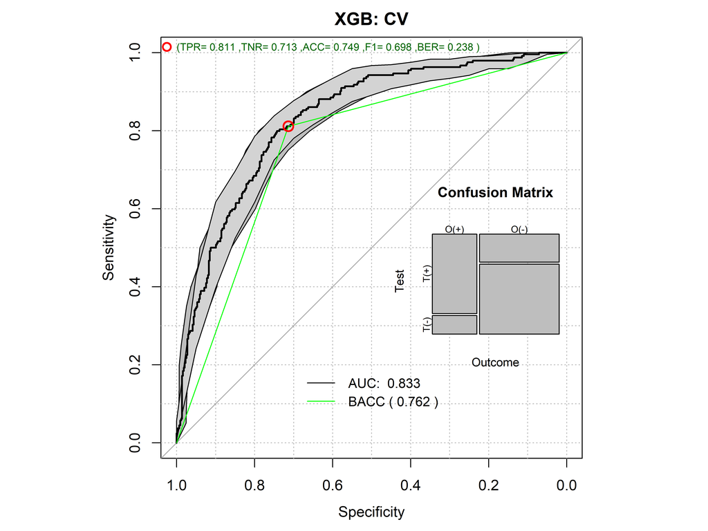

### 2.4.2 ILAA XGB

```r
ILAAXGBcv <- randomCV(fittingFunction = filteredFit,
                     trainSampleSets = XBOOSTcv$trainSamplesSets,
                     fitmethod = s3xgb,
                      filtermethod = NULL,
                    DECOR = TRUE,
                    DECOR.control=list(thr=thro)
                    )
```

……….10 Tested: 647 Avg. Selected: 327 Min Tests: 1 Max Tests: 9 Mean Tests: 4.482226 . MAD: 0.3074791

……….20 Tested: 679 Avg. Selected: 327 Min Tests: 1 Max Tests: 17 Mean Tests: 8.541973 . MAD: 0.3072833

……….30 Tested: 680 Avg. Selected: 327 Min Tests: 1 Max Tests: 23 Mean Tests: 12.79412 . MAD: 0.3026484

……….40 Tested: 680 Avg. Selected: 327 Min Tests: 3 Max Tests: 31 Mean Tests: 17.05882 . MAD: 0.3010327

……….50 Tested: 680 Avg. Selected: 327 Min Tests: 3 Max Tests: 37 Mean Tests: 21.32353 . MAD: 0.2999642

```r
ILAAXGBbs <- predictionStats_binary(ILAAXGBcv$medianTest,"ILAA-XGB: CV")
```

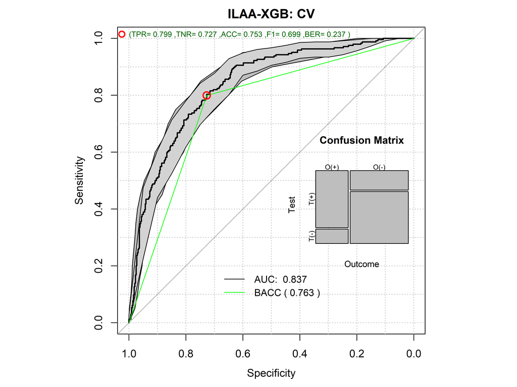

### 2.4.3 LASSO

```r
LASSOcv <- randomCV(fittingFunction = LASSO_MIN,
                     trainSampleSets = XBOOSTcv$trainSamplesSets,
                    family="binomial")
```

……….10 Tested: 647 Avg. Selected: 18.9 Min Tests: 1 Max Tests: 9 Mean Tests: 4.482226 . MAD: 0.346587

……….20 Tested: 679 Avg. Selected: 18.95 Min Tests: 1 Max Tests: 17 Mean Tests: 8.541973 . MAD: 0.3472724

……….30 Tested: 680 Avg. Selected: 19.46667 Min Tests: 1 Max Tests: 23 Mean Tests: 12.79412 . MAD: 0.3479973

……….40 Tested: 680 Avg. Selected: 20.45 Min Tests: 3 Max Tests: 31 Mean Tests: 17.05882 . MAD: 0.3464839

……….50 Tested: 680 Avg. Selected: 20.34 Min Tests: 3 Max Tests: 37 Mean Tests: 21.32353 . MAD: 0.3464869

```r
LASSObs <- predictionStats_binary(LASSOcv$medianTest,"LASSO: CV")
```

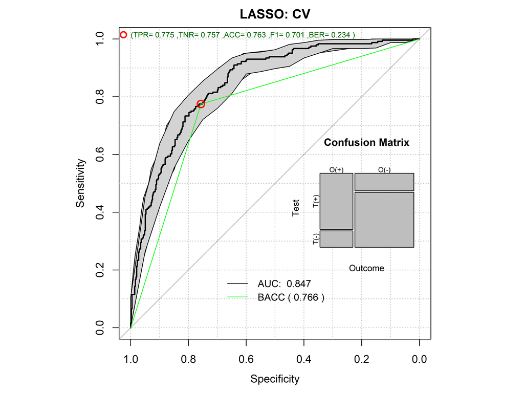

### 2.4.4 ILAA LASSO

```r
ILAALASSOcv <- randomCV(fittingFunction = filteredFit,
                     trainSampleSets = XBOOSTcv$trainSamplesSets,
                     fitmethod = LASSO_MIN,
                      filtermethod = NULL,
                    DECOR = TRUE,
                    DECOR.control=list(thr=thro),
                    family="binomial")
```

……….10 Tested: 647 Avg. Selected: 19.1 Min Tests: 1 Max Tests: 9 Mean Tests: 4.482226 . MAD: 0.3501219

……….20 Tested: 679 Avg. Selected: 19.8 Min Tests: 1 Max Tests: 17 Mean Tests: 8.541973 . MAD: 0.3490438

……….30 Tested: 680 Avg. Selected: 22.06667 Min Tests: 1 Max Tests: 23 Mean Tests: 12.79412 . MAD: 0.3483599

……….40 Tested: 680 Avg. Selected: 25.825 Min Tests: 3 Max Tests: 31 Mean Tests: 17.05882 . MAD: 0.3458302

……….50 Tested: 680 Avg. Selected: 26.24 Min Tests: 3 Max Tests: 37 Mean Tests: 21.32353 . MAD: 0.3451044

```r
ILAALASSObs <- predictionStats_binary(ILAALASSOcv$medianTest,"ILLA-LASSO: CV")
```

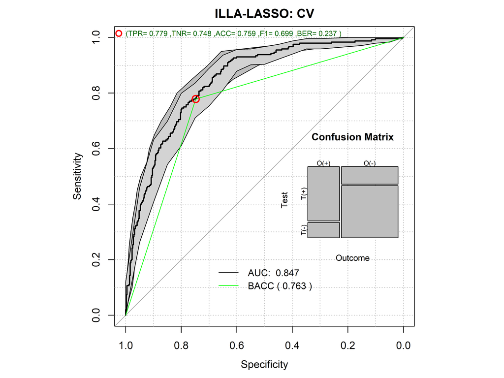

### 2.4.5 SVM

```r
SVMcv <- randomCV(fittingFunction = filteredFit,
                  trainSampleSets = XBOOSTcv$trainSamplesSets,
                  asFactor = TRUE,
                  filtermethod = multivariate_BinEnsemble,
                  filtermethod.control=NULL,
                  probability=TRUE)
```

………..10 Tested: 647 Avg. Selected: 163.4 Min Tests: 1 Max Tests: 9 Mean Tests: 4.482226 . MAD: 0.3419812

……….20 Tested: 679 Avg. Selected: 162.9 Min Tests: 1 Max Tests: 17 Mean Tests: 8.541973 . MAD: 0.3407393

……….30 Tested: 680 Avg. Selected: 162.1 Min Tests: 1 Max Tests: 23 Mean Tests: 12.79412 . MAD: 0.3400033

……….40 Tested: 680 Avg. Selected: 161.9 Min Tests: 3 Max Tests: 31 Mean Tests: 17.05882 . MAD: 0.3399509

……….50 Tested: 680 Avg. Selected: 161.94 Min Tests: 3 Max Tests: 37 Mean Tests: 21.32353 . MAD: 0.3406119

```r
SVMbs <- predictionStats_binary(SVMcv$medianTest,"SVM: CV")
```

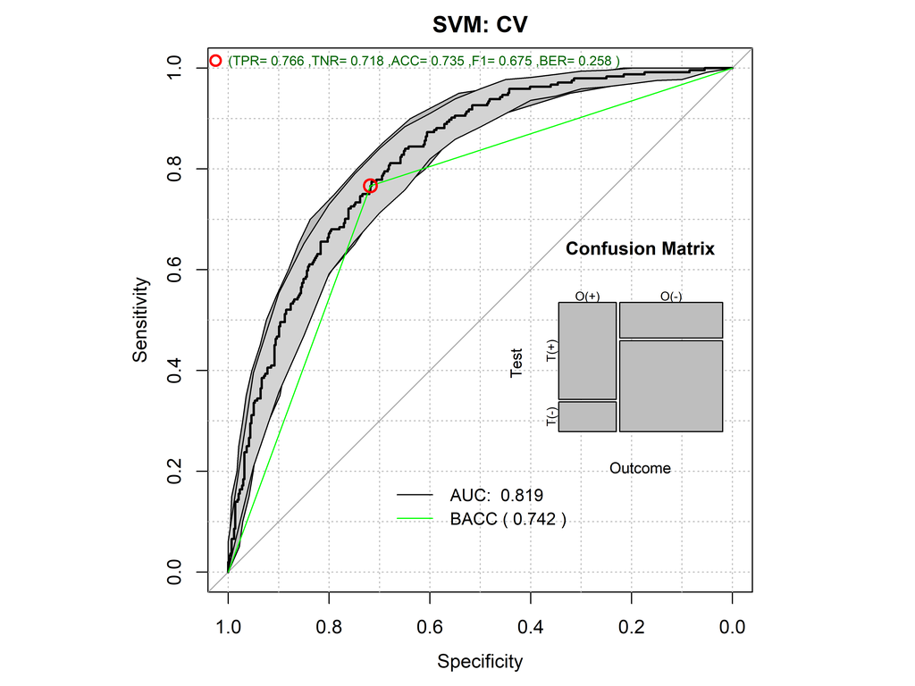

### 2.4.6 ILAAA SVM

```r
ILLASVMcv <- randomCV(dataframe,outcome,fittingFunction = filteredFit,
                  trainSampleSets = XBOOSTcv$trainSamplesSets,
                  asFactor = TRUE,
                  DECOR = TRUE,
                  DECOR.control=list(thr=thro),
                  filtermethod = multivariate_BinEnsemble,
                  filtermethod.control=NULL,
                  probability=TRUE)
```

……….10 Tested: 647 Avg. Selected: 150.4 Min Tests: 1 Max Tests: 9 Mean Tests: 4.482226 . MAD: 0.3441824

………..20 Tested: 679 Avg. Selected: 149.35 Min Tests: 1 Max Tests: 17 Mean Tests: 8.541973 . MAD: 0.3440847

………..30 Tested: 680 Avg. Selected: 148.6333 Min Tests: 1 Max Tests: 23 Mean Tests: 12.79412 . MAD: 0.341584

……….40 Tested: 680 Avg. Selected: 149.125 Min Tests: 3 Max Tests: 31 Mean Tests: 17.05882 . MAD: 0.3401428

……….50 Tested: 680 Avg. Selected: 149.38 Min Tests: 3 Max Tests: 37 Mean Tests: 21.32353 . MAD: 0.3408753

```r
ILLASVMbs <- predictionStats_binary(ILLASVMcv$medianTest,"ILLA-SVM: CV")
```

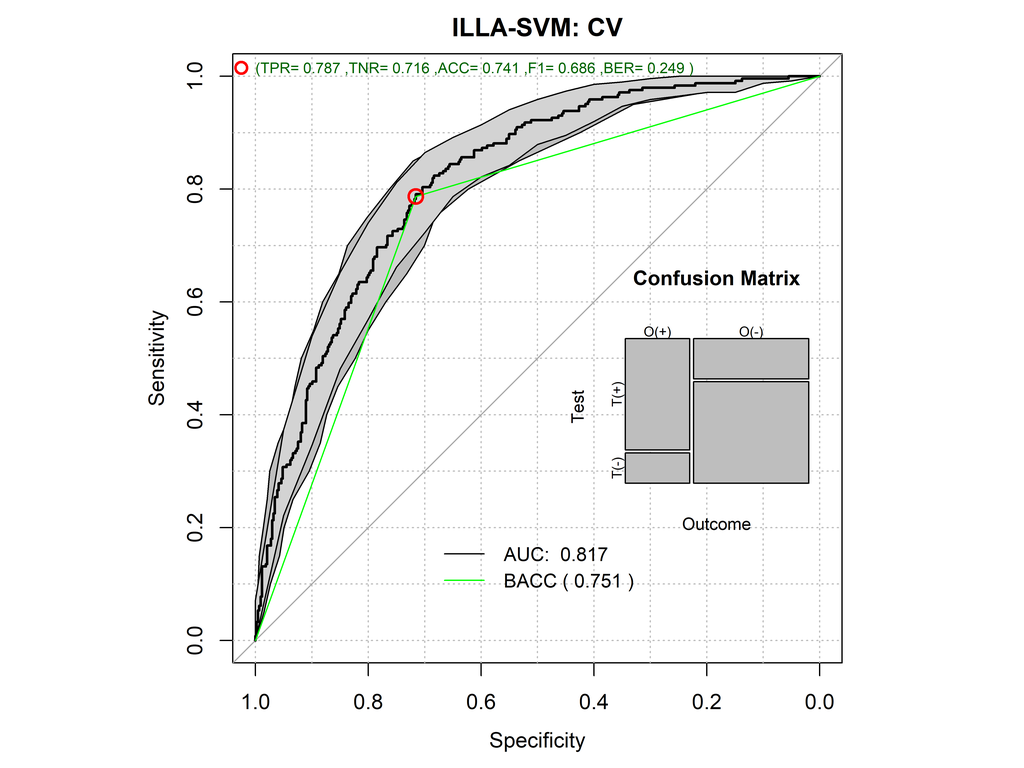

## 2.5 The Reports

```r
par(op)
AUCTABLE <- rbind(
                  XGBbs$aucs,
                  SVMbs$aucs,
                  LASSObs$aucs,
                  ILAAXGBbs$aucs,
                  ILLASVMbs$aucs,
                  ILAALASSObs$aucs
                  )
colnames(AUCTABLE) <- c("Median","Lower","Upper")
rownames(AUCTABLE) <- c("XGB","SVM","LASSO",
                        "ILAA-XGB","ILAA-SVM","ILAA-LASSO")

pander::pander(AUCTABLE)
```

|  | Median | Lower | Upper |
| --- | --- | --- | --- |
| **XGB** | 0.833 | 0.802 | 0.864 |
| **SVM** | 0.819 | 0.788 | 0.851 |
| **LASSO** | 0.847 | 0.817 | 0.876 |
| **ILAA-XGB** | 0.837 | 0.806 | 0.867 |
| **ILAA-SVM** | 0.817 | 0.785 | 0.849 |
| **ILAA-LASSO** | 0.847 | 0.818 | 0.877 |

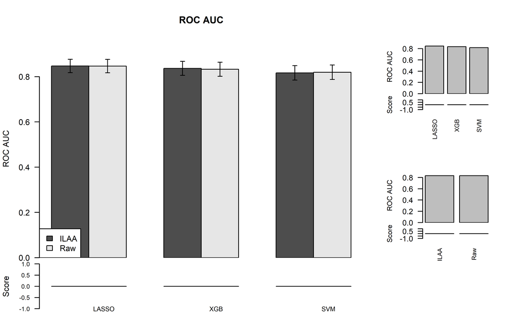

```r
thesets <- c("XGB","SVM","LASSO")
themethod <- c("Raw","ILAA")
pauc <- barPlotCiError(AUCTABLE,
               "ROC AUC",
               thesets=thesets,
               themethod=themethod,
               main="ROC AUC",
               angle=0,
               offsets=c(0.1,1.0),
               scoreDirection=">",args.legend=list(x="bottomleft"))

par(op)
```

```r
BERTABLE <- rbind(
                  XGBbs$berror,
                  SVMbs$berror,
                  LASSObs$berror,
                  ILAAXGBbs$berror,
                  ILLASVMbs$berror,
                  ILAALASSObs$berror
                  )


colnames(BERTABLE) <- colnames(AUCTABLE)
rownames(BERTABLE) <- rownames(AUCTABLE)

pander::pander(BERTABLE)
```

|  | Median | Lower | Upper |
| --- | --- | --- | --- |
| **XGB** | 0.237 | 0.204 | 0.270 |
| **SVM** | 0.258 | 0.225 | 0.291 |
| **LASSO** | 0.235 | 0.202 | 0.268 |
| **ILAA-XGB** | 0.237 | 0.206 | 0.269 |
| **ILAA-SVM** | 0.248 | 0.217 | 0.284 |
| **ILAA-LASSO** | 0.236 | 0.203 | 0.271 |

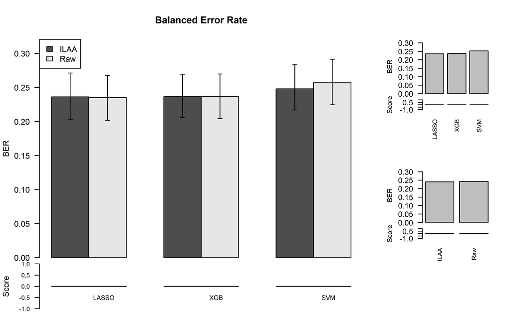

```r
pber <- barPlotCiError(BERTABLE,
               "BER",
               thesets=thesets,
               themethod=themethod,
               main="Balanced Error Rate",
               angle=0,
               offsets=c(0.1,0.5),
               scoreDirection="<",args.legend=list(x="topleft"))
```

### 2.5.1 Saving ALL

```r
save.image(paste("SOTACV_analyiss",studyName,".RData",sep="_"))
```